# Predicting Solved Murders in the US

Nick Pongratz

3/20/2017

# Part I. Data Cleaning and Exploration

## Dataset

The dataset being used for this project is Homicide Reports, 1980 - 2014, which can be retrieved at the link below. It is a collection of data on homicides throughout the United States collected by the FBI, or made available by the Freedom of Information Act. The dataset consists of *N = 638454* observations, with *p = 24 predictors*. For this project I will endeavor to derive a model to determine whether a murder will be solved or not. In discussing the predictors a number of them will be dropped as well as the number of observations.

## Initialization and Loading the Data

First, I must load the libraries I will need to analyze the data, as well as the dataset itself. Data Tables provide some conveniences for analysis, such as subsetting the data without having to use another function.

```r
library(data.table)
library(ggplot2)
library(descr)
library(pander)
library(knitr)
library(gridExtra)

opts_chunk$set(cache=TRUE)
rawdata <- data.table(read.csv('/Users/pongnick/Desktop/database.csv'))
data<-rawdata
```

## Predictors and Predicted Variable

The initial 24 predictors are as follows:  
**Record.ID:** Unique number assigned to reported incident  
**Agency.Code:** Unique code assigned to local agency  
**Agency.Name:** Name of local agency  
**Agency.Type:** Type of local agency  
**City:** City where incident occurred  
**State:** State where incident occurred  
**Year:** Year when incident occurred  
**Month:** Month when incident occurred  
**Incident:** Unknown  
**Crime.Type:** Type of crime committed  
*Crime.Solved:* Whether or not the crime was solved  
**Victim.Sex:** Sex of the victim  
**Victim.Age** Age of the victim  
**Victim.Race:** Race of the victim  
**Victim.Ethnicity:** Ethnicity of the victim  
**Perpetrator.Sex:** Sex of the perpetrator  
**Perpetrator.Age:** Age of the perpetrator  
**Perpetrator.Race:** Race of the perpetrator  
**Perpetrator.Ethnicity:** Ethnicity of the perpetrator  
**Relationship:** Relationship between the victim and the perpetrator  
**Weapon:** Weapon used in incident  
**Victim.Count:** Number of victims in incident  
**Perpetrator.Count:** Number of perpetrators in incident  
**Record.Source:** Source of the record

```r
pander(summary(data))
```

Table continues below

| Record.ID | Agency.Code | Agency.Name | Agency.Type |
| --- | --- | --- | --- |
| Min. : 1 | NY03030: 38416 | New York : 38416 | County Police : 22693 |
| 1st Qu.:159614 | CA01942: 23663 | Los Angeles : 29007 | Municipal Police:493026 |
| Median :319228 | ILCPD00: 21331 | Chicago : 21331 | Regional Police : 235 |
| Mean :319228 | MI82349: 17206 | Detroit : 17206 | Sheriff :105322 |
| 3rd Qu.:478841 | TXHPD00: 12881 | Houston : 13046 | Special Police : 2889 |
| Max. :638454 | PAPEP00: 12848 | Philadelphia: 12861 | State Police : 14235 |
| NA | (Other):512109 | (Other) :506587 | Tribal Police : 54 |

Table continues below

| City | State | Year | Month |
| --- | --- | --- | --- |
| Los Angeles : 44511 | California: 99783 | Min. :1980 | July : 58696 |
| New York : 38431 | Texas : 62095 | 1st Qu.:1987 | August : 58072 |
| Cook : 22383 | New York : 49268 | Median :1995 | December : 55187 |
| Wayne : 19904 | Florida : 37164 | Mean :1996 | September: 54117 |
| Harris : 16331 | Michigan : 28448 | 3rd Qu.:2004 | June : 53662 |
| Philadelphia: 12851 | Illinois : 25871 | Max. :2014 | October : 53650 |
| (Other) :484043 | (Other) :335825 | NA | (Other) :305070 |

Table continues below

| Incident | Crime.Type | Crime.Solved | Victim.Sex |
| --- | --- | --- | --- |
| Min. : 0.00 | Manslaughter by Negligence: 9116 | No :190282 | Female :143345 |
| 1st Qu.: 1.00 | Murder or Manslaughter :629338 | Yes:448172 | Male :494125 |
| Median : 2.00 | NA | NA | Unknown: 984 |
| Mean : 22.97 | NA | NA | NA |
| 3rd Qu.: 10.00 | NA | NA | NA |
| Max. :999.00 | NA | NA | NA |
| NA | NA | NA | NA |

Table continues below

| Victim.Age | Victim.Race | Victim.Ethnicity |
| --- | --- | --- |
| Min. : 0.00 | Asian/Pacific Islander : 9890 | Hispanic : 72652 |
| 1st Qu.: 22.00 | Black :299899 | Not Hispanic:197499 |
| Median : 30.00 | Native American/Alaska Native: 4567 | Unknown :368303 |
| Mean : 35.03 | Unknown : 6676 | NA |
| 3rd Qu.: 42.00 | White :317422 | NA |
| Max. :998.00 | NA | NA |
| NA | NA | NA |

Table continues below

| Perpetrator.Sex | Perpetrator.Age | Perpetrator.Race |
| --- | --- | --- |
| Female : 48548 | Min. : 0.00 | Asian/Pacific Islander : 6046 |
| Male :399541 | 1st Qu.: 0.00 | Black :214516 |
| Unknown:190365 | Median :21.00 | Native American/Alaska Native: 3602 |
| NA | Mean :20.32 | Unknown :196047 |
| NA | 3rd Qu.:31.00 | White :218243 |
| NA | Max. :99.00 | NA |
| NA | NA’s :1 | NA |

Table continues below

| Perpetrator.Ethnicity | Relationship | Weapon | Victim.Count |
| --- | --- | --- | --- |
| Hispanic : 46872 | Unknown :273013 | Handgun :317484 | Min. : 0.0000 |
| Not Hispanic:145172 | Acquaintance:126018 | Knife : 94962 | 1st Qu.: 0.0000 |
| Unknown :446410 | Stranger : 96593 | Blunt Object: 67337 | Median : 0.0000 |
| NA | Wife : 23187 | Firearm : 46980 | Mean : 0.1233 |
| NA | Friend : 21945 | Unknown : 33192 | 3rd Qu.: 0.0000 |
| NA | Girlfriend : 16465 | Shotgun : 30722 | Max. :10.0000 |
| NA | (Other) : 81233 | (Other) : 47777 | NA |

| Perpetrator.Count | Record.Source |
| --- | --- |
| Min. : 0.0000 | FBI :616647 |
| 1st Qu.: 0.0000 | FOIA: 21807 |
| Median : 0.0000 | NA |
| Mean : 0.1852 | NA |
| 3rd Qu.: 0.0000 | NA |
| Max. :10.0000 | NA |
| NA | NA |

## Dropping Variables

We remove the ID number to prevent data leakage.

```r
data[,Record.ID:=NULL]
```

We remove Agency Code, Agency Name, and City because all of these predictors have too many factors for R to handle. As it is unclear what the incident predictors represents, we remove it as well.

```r
data[,Agency.Code:=NULL]
data[,Agency.Name:=NULL]
data[,City:=NULL]
data[,Incident:=NULL]
data[,State:=substr(State,1,3)]
```

We remove information about the perpetrator, because none of this information is known in cases when the murder is not solved and so it would skew the results.

```r
table(data$Perpetrator.Sex,data$Crime.Solved)
```

```
##
##               No    Yes
##   Female       5  48543
##   Male        59 399482
##   Unknown 190218    147
```

```r
data[,Perpetrator.Sex:=NULL]
data[,Perpetrator.Age:=NULL]
data[,Perpetrator.Race:=NULL]
data[,Perpetrator.Ethnicity:=NULL]
data[,Relationship:=NULL]
data<-data[,Perpetrator.Count:=NULL]
```

Since we are only interested in cases where there are victims, and where these victims have ages that makes sense, we eliminate observations where the victim count is zero and the age is 99 or above. It’s curious why these would be included at all, but I remove them here for the purposes of my analysis.

```r
data<-data[Victim.Count>0,]
data<-data[Victim.Age<99]
```

So now we are left with a dataset of *N = 51426* observations, and *p = 13* variables.

# Exploratory Data Analysis

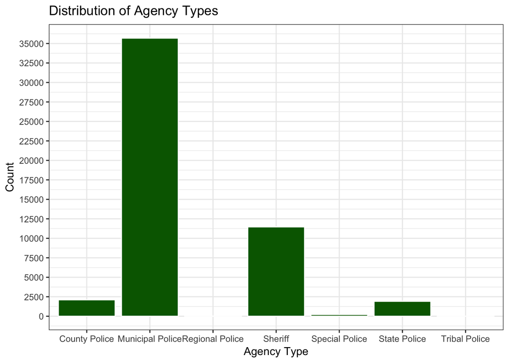

Here we can see most incidents are handled by the Municipal Police Departments.

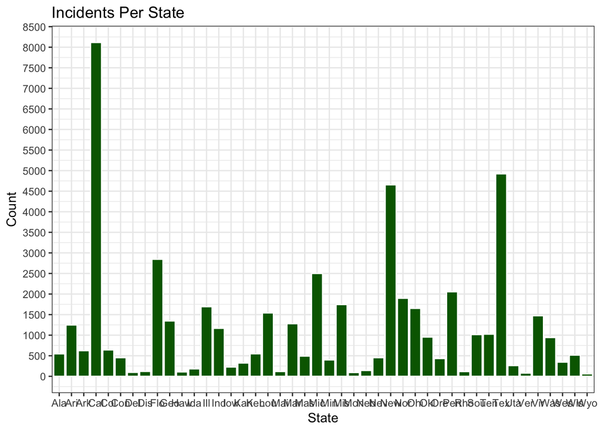

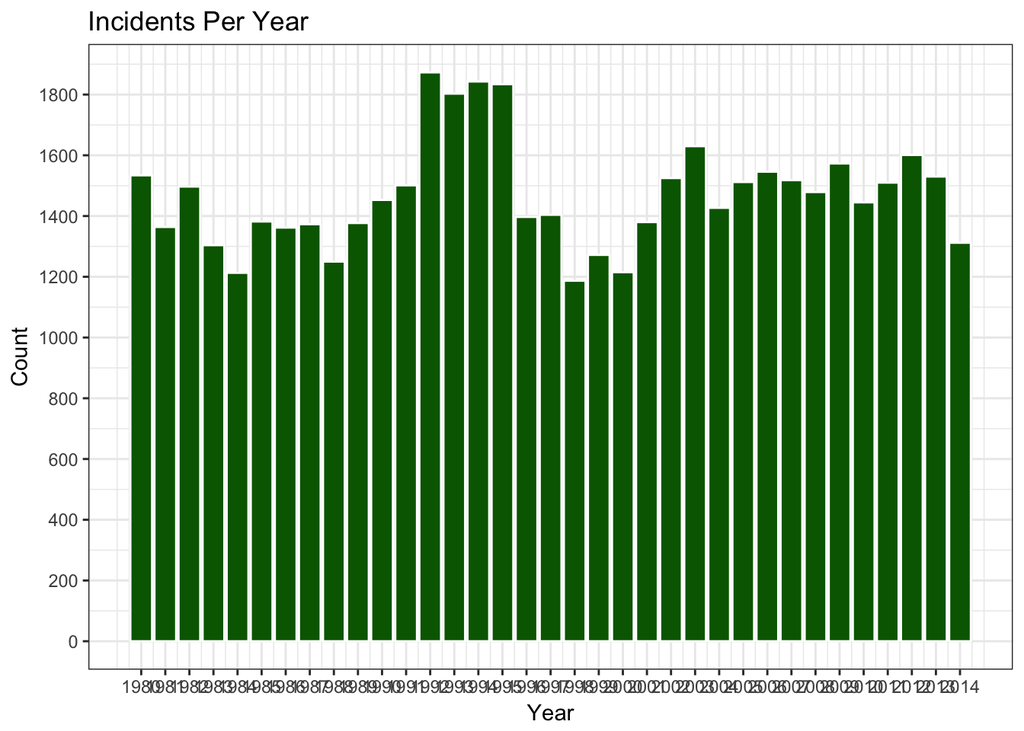

Here we can see a relative spike during the early 1990’s (’92-’95), with a significant drop in 1996.

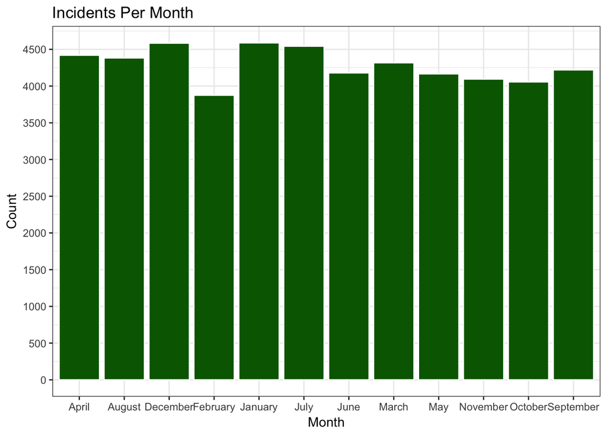

Here we can see that the incidents are spread relatively even throughout the year, hovering around or above 4000, with the exception of February.

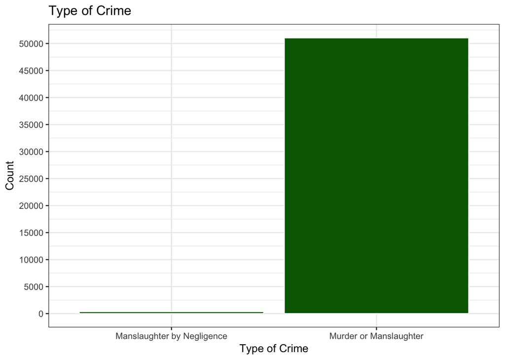

Here we can see that a majority of the incidents were not the result of negligence.

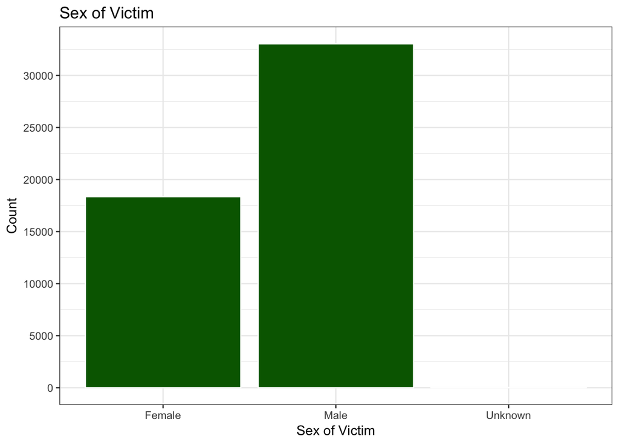

Here we can see that there are almost twice as many male victims as female.

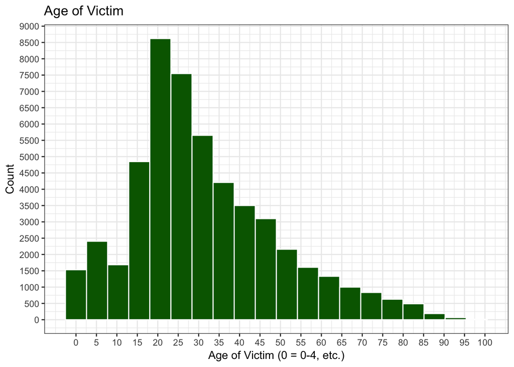

Here we can see that the largest proportion of the victims are in their twenties.

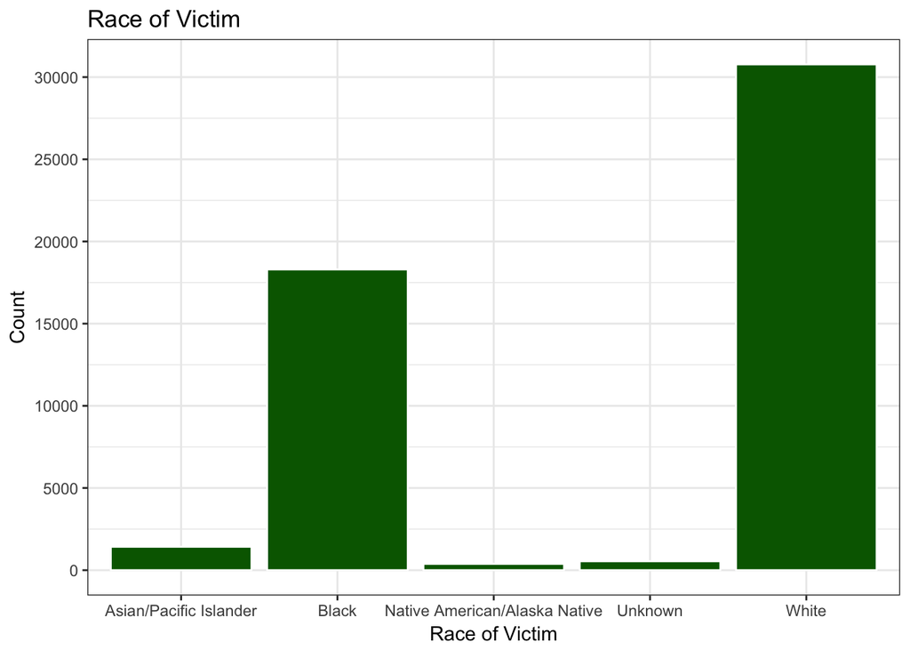

Here we can see that most victims are white, with a large proportion of them being black as well.

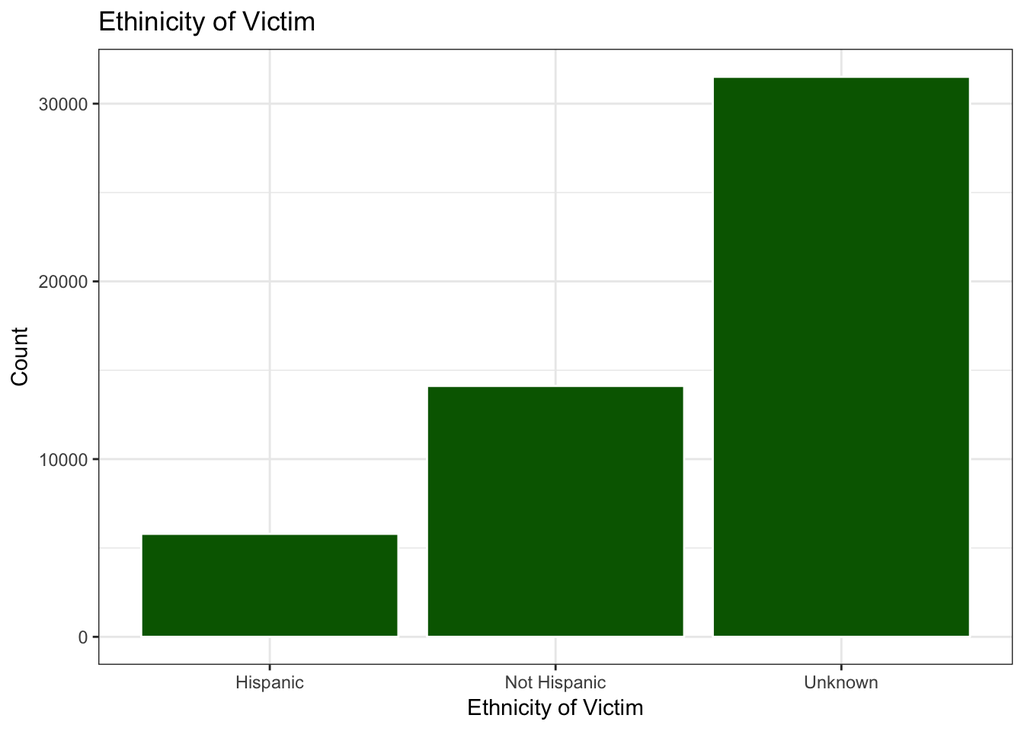

Here we can see that, according to the criteria set by the compilers of this data, the ethnicity is mostly unknown, so it will likely not play a large factor.

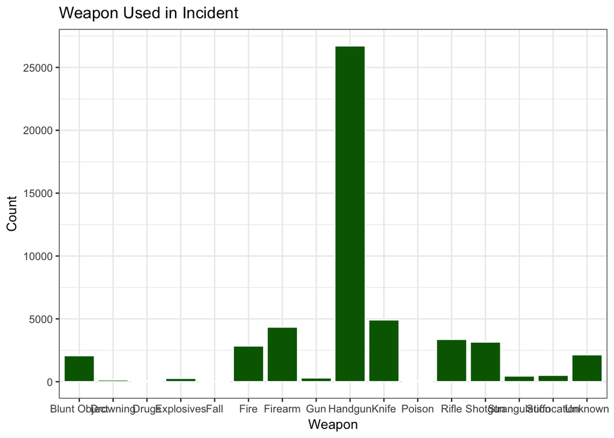

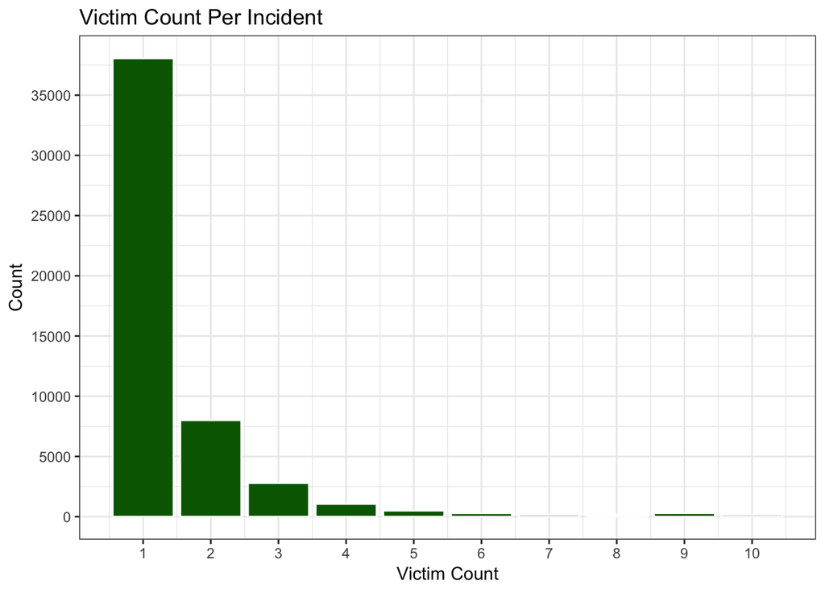

Here we can see that in most cases there was only a single victim involved in the incident.

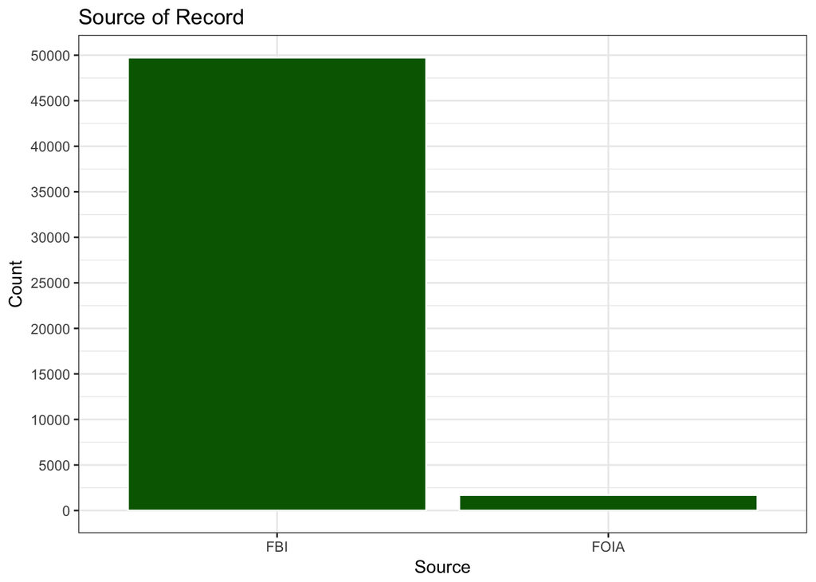

Finally, here we see that most of these records were attained through the FBI.

## Part 2 Machine Learning

At this point I take my dataset and separate it into training, validation, and test sets. Then using the Random Forest and GBM methods, I train a model using the training set, which includes cross-validation, utilizing the validation set. Once the model has run grid search is used to find the optimal model it is tested on the test set, and its accuracy is displayed using an ROC curve.

# Load the Library and Data

First I load the H20 library, I will use to to do machine learning, then initiate it, using utilizing the six cores of my computer’s processer. I remove anything that may already be there and then upload the data as a dataframe.

```r
library(h2o)
h2o.init(nthreads = 6)
h2o.removeAll()
df<-data
h2o_d<-as.h2o(df)
```

# Split the Data

Here the data is split into a training, validation and test sets, at a proportion of 0.6, 0.2, and 0.2 respectively, while also setting a seed to make the results reproducible.

```r
h2o_sd<- h2o.splitFrame(h2o_d, ratios = c(.6, 0.2),seed=4321)
names(h2o_sd) <- c('train', 'valid', 'test')
```

# Run Random Forest

Here I run the first method, Random Forest. First I remove anything that may already have the title ‘RF’ from the workspace. The I create a new variable called ‘RF’, which uses the ‘randomForest’ algorithm, has the hyperparameters set and 15, 20 and 25 levels of depth, with 3, 5, and 7 predictors per tree. I use the training set as the training frame, the validation set as the validation frame, all of the columns as predictor, to try and predict whether a crime will be solved. I set the number of trees at 100, and the number of folds for cross-validation at 5.

```r
h2o.rm("RF")

RF <- h2o.grid(
  algorithm = "randomForest",
  grid_id = "RF",
  hyper_params = list(max_depth=c(15,20,25),mtries=c(3,5,7)),
  training_frame = h2o_sd$train,
  validation_frame = h2o_sd$valid,
  x=colnames(h2o_sd$train),
  y="Crime.Solved",
  seed=4321,
  ntrees=100,
  nfolds=5
)
```

Once I have the results I use grid search to list all the models it produced by order of decreasing accuracy, thus giving me the most accurate model at the top of the list, which is the displayed with the best level depth and the best amount of predictors.

```r
RFm<-h2o.getGrid(
  grid_id = "RF",
  sort_by = "AUC",
  decreasing = TRUE
)
```

```r
RFm
```

```
## H2O Grid Details
## ================
##
## Grid ID: RF
## Used hyper parameters:
##   -  max_depth
##   -  mtries
## Number of models: 9
## Number of failed models: 0
##
## Hyper-Parameter Search Summary: ordered by decreasing AUC
##   max_depth mtries  model_ids                auc
## 1        20      3 RF_model_1 0.7647681726150091
## 2        25      3 RF_model_2  0.761669379462292
## 3        20      7 RF_model_7 0.7613383056430836
## 4        20      5 RF_model_4 0.7609525760745507
## 5        15      7 RF_model_6 0.7604765837378831
## 6        15      5 RF_model_3 0.7588015984687964
## 7        15      3 RF_model_0 0.7582441676207582
## 8        25      7 RF_model_8 0.7563307881854514
## 9        25      5 RF_model_5 0.7558729986695994
```

```r
RFb<- h2o.getModel(RFm@model_ids[[1]])
RFb@parameters$max_depth
```

[output not shown]

```r
RFb@parameters$mtries
```

```
## [1] 3
```

# Visualize Results with Test Set

To provide a visualiztion for these results I must extract the relevant information from the model, put them into new variables which I then visualize with ggplot. The results of the training model are displaye alongside the results from the model’s success on the test set.

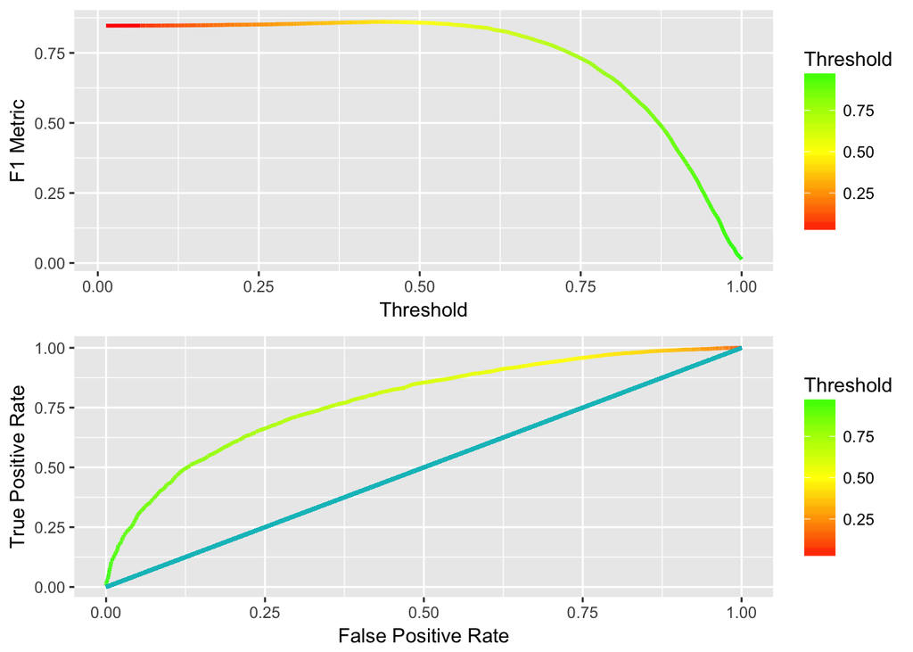

```r
RFp<-h2o.performance(RFb,valid=T)
h2o.auc(RFp)
RFrp<-cbind(h2o.fpr(RFp),h2o.tpr(RFp)$tpr)
colnames(RFrp)[3]<-"tpr"
RFt<-h2o.performance(RFb,newdata = h2o_sd$test)
RFrt<-cbind(h2o.fpr(RFt),h2o.tpr(RFt)$tpr)
h2o.auc(RFt)
colnames(RFrt)[3]<-"tpr"

RFev<-ggplot(h2o.F1(RFp)) +
  geom_line(aes(x=threshold,y=f1,color=threshold),size=1) +
  scale_color_gradient2("Threshold",low="red",high="green",mid="yellow",midpoint = 0.5) +
  labs(x="Threshold",y="F1 Metric")

RFet<-ggplot(h2o.F1(RFt)) +
  geom_line(aes(x=threshold,y=f1,color=threshold),size=1) +
  scale_color_gradient2("Threshold",low="red",high="green",mid="yellow",midpoint = 0.5) +
  labs(x="Threshold",y="F1 Metric")

RFav<-ggplot(RFrp,aes(x=fpr,y=tpr)) +
  geom_line(aes(col=threshold),size=1) +
  labs(x="False Positive Rate",y="True Positive Rate") +
  scale_color_gradient2("Threshold",low="red",high="green",mid="yellow",midpoint = 0.5) +
  geom_segment(x=0,y=0,xend=1,yend=1,size=1,col="#00BFC4")

RFat<-ggplot(RFrt,aes(x=fpr,y=tpr)) +
  geom_line(aes(col=threshold),size=1) +
  labs(x="False Positive Rate",y="True Positive Rate") +
  scale_color_gradient2("Threshold",low="red",high="green",mid="yellow",midpoint = 0.5)+
  geom_segment(x=0,y=0,xend=1,yend=1,size=1,col="#00BFC4")

grid.arrange(RFev,RFav,ncol=1)
```

[output not shown]

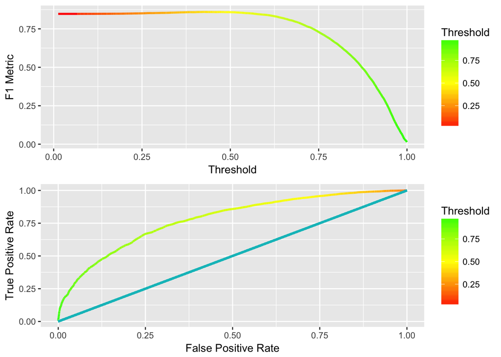

```r
grid.arrange(RFet,RFat,ncol=1)
```

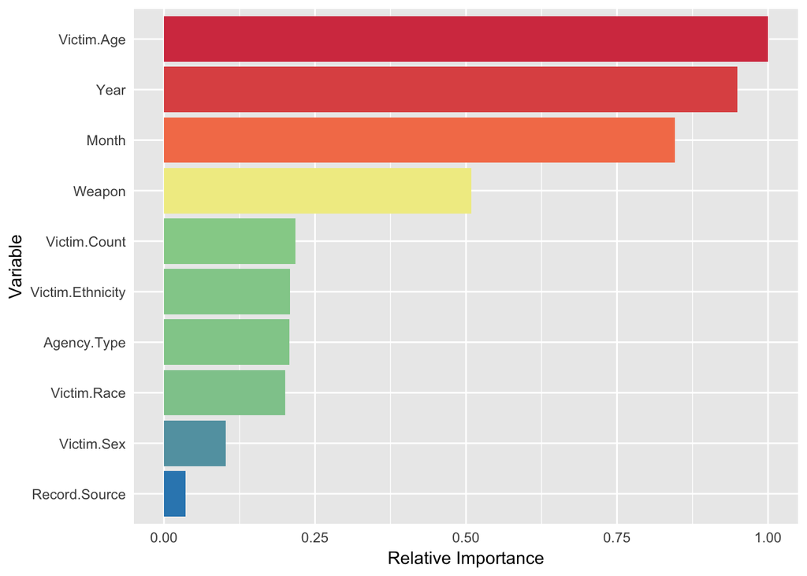

```r
ggplot(data.table(cbind(h2o.varimp(RFb)$variable[1:10],h2o.varimp(RFb)$scaled_importance[1:10],h2o.varimp(RFb)$relative_importance[1:10]))) +
  geom_col(aes(x=V1,y=as.numeric(V2),fill=as.numeric(V3))) +
  coord_flip() +
  scale_x_discrete(limits=rev(h2o.varimp(RFb)$variable[1:10])) +
  scale_y_continuous(breaks=seq(0,1,0.25)) +
  theme(axis.ticks=element_blank()) +
  labs(x="Variable",y="Relative Importance") +
  scale_fill_distiller(palette="Spectral",guide=F)
```

Finally we display the confusions matrix, which shows the number of True and False Positive the model creates.

```r
h2o.confusionMatrix(RFp,metric="min_per_class_accuracy")[,1:3]
```

```
##          No  Yes     Error
## No     1933  797 0.2919414
## Yes    2220 5351 0.2932241
## Totals 4153 6148 0.2928842
```

```r
h2o.confusionMatrix(RFt,metric="min_per_class_accuracy")[,1:3]
```

```
##          No  Yes     Error
## No     1933  793 0.2909024
## Yes    2214 5360 0.2923158
## Totals 4147 6153 0.2919417
```

# Run GBM

Now I will try running a different model, to see what the variability is in accuracy and what the determinant predictors are.First I remove anything that may already have the title ‘GBM’ from the workspace. The I create a new variable called ‘GBM’, which uses the ‘gbm’ algorithm, has the hyperparameters set and 4, 5 and 6 levels of depth, with learn rate of 0.06, 0.07, 0.08, 0.09, and 0.1. I use the training set as the training frame, the validation set as the validation frame, all of the columns as predictor, to try and predict whether a crime will be solved. I set the number of trees at 100, and the number of folds for cross-validation at 5.

```r
h2o.rm("GBM") # Remove anything already GBM

GBM <- h2o.grid(
  algorithm = "gbm",
  grid_id = "GBM",
  hyper_params = list(max_depth=c(4,5,6),learn_rate=c(0.06,0.07,0.08,0.09,0.1)), #
  training_frame = h2o_sd$train,
  validation_frame = h2o_sd$valid,
  x=colnames(h2o_sd$train),
  y="Crime.Solved",
  seed=4321,
  ntrees=100,
  nfolds=5
)
```

Once I have the results I use grid search to list all the models it produced by order of decreasing accuracy, thus giving me the most accurate model at the top of the list, which is the displayed with the best level depth and the best learning rate.

```r
GBMm<-h2o.getGrid(
  grid_id = "GBM",
  sort_by = "AUC",
  decreasing = TRUE
)
```

```r
GBMm
```

```
## H2O Grid Details
## ================
##
## Grid ID: GBM
## Used hyper parameters:
##   -  learn_rate
##   -  max_depth
## Number of models: 15
## Number of failed models: 0
##
## Hyper-Parameter Search Summary: ordered by decreasing AUC
##    learn_rate max_depth    model_ids                auc
## 1         0.1         6 GBM_model_14 0.7347798515280313
## 2        0.09         6 GBM_model_13 0.7331486512805255
## 3        0.08         6 GBM_model_12 0.7320259399627729
## 4        0.07         6 GBM_model_11 0.7309640684671114
## 5        0.06         6 GBM_model_10 0.7286058403581143
## 6         0.1         5  GBM_model_9  0.727104174630565
## 7        0.09         5  GBM_model_8  0.726119002450322
## 8        0.08         5  GBM_model_7 0.7249101213063931
## 9        0.07         5  GBM_model_6  0.722769975022651
## 10       0.06         5  GBM_model_5 0.7211504020929299
## 11        0.1         4  GBM_model_4 0.7177135130196851
## 12       0.09         4  GBM_model_3 0.7166480267049383
## 13       0.08         4  GBM_model_2  0.716214716029375
## 14       0.07         4  GBM_model_1 0.7143930941529439
## 15       0.06         4  GBM_model_0 0.7130159768068164
```

```r
GBMb<- h2o.getModel(GBMm@model_ids[[1]])
GBMb@parameters$learn_rate
```

[output not shown]

```r
GBMb@parameters$max_depth
```

```
## [1] 6
```

# Visualize Results with Test Set

To provide a visualiztion for these results I must extract the relevant information from the model, put them into new variables which I then visualize with ggplot. The results of the training model are displaye alongside the results from the model’s success on the test set.

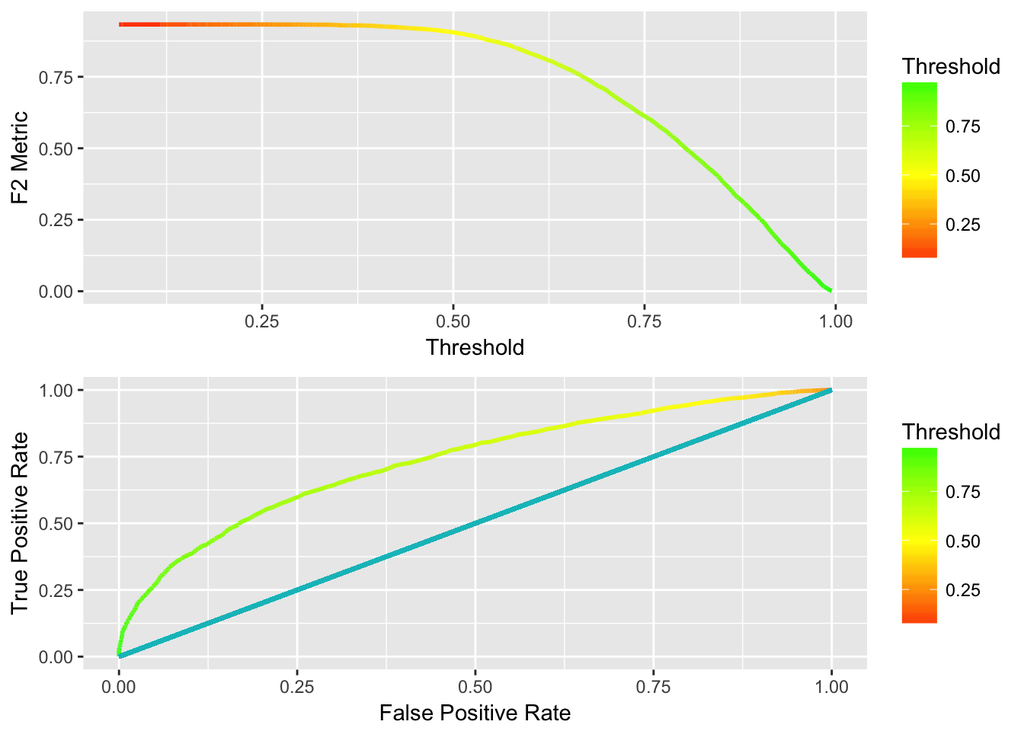

```r
GBMp<-h2o.performance(GBMb,valid=T)
h2o.auc(GBMp)
GBMrp<-cbind(h2o.fpr(GBMp),h2o.tpr(GBMp)$tpr)
colnames(GBMrp)[3]<-"tpr"
GBMt<-h2o.performance(GBMb,newdata = h2o_sd$test)
GBMrt<-cbind(h2o.fpr(GBMt),h2o.tpr(GBMt)$tpr)
h2o.auc(GBMt)
colnames(GBMrt)[3]<-"tpr"

GBMev<-ggplot(h2o.F2(GBMp)) +
  geom_line(aes(x=threshold,y=f2,color=threshold),size=1) +
  scale_color_gradient2("Threshold",low="red",high="green",mid="yellow",midpoint = 0.5) +
  labs(x="Threshold",y="F2 Metric")

GBMet<-ggplot(h2o.F2(GBMt)) +
  geom_line(aes(x=threshold,y=f2,color=threshold),size=1) +
  scale_color_gradient2("Threshold",low="red",high="green",mid="yellow",midpoint = 0.5) +
  labs(x="Threshold",y="F2 Metric")

GBMav<-ggplot(GBMrp,aes(x=fpr,y=tpr)) +
  geom_line(aes(col=threshold),size=1) +
  labs(x="False Positive Rate",y="True Positive Rate") +
  scale_color_gradient2("Threshold",low="red",high="green",mid="yellow",midpoint = 0.5)+
  geom_segment(x=0,y=0,xend=1,yend=1,size=1,col="#00BFC4")

GBMat<-ggplot(GBMrt,aes(x=fpr,y=tpr)) +
  geom_line(aes(col=threshold),size=1) +
  labs(x="False Positive Rate",y="True Positive Rate") +
  scale_color_gradient2("Threshold",low="red",high="green",mid="yellow",midpoint = 0.5) +
  geom_segment(x=0,y=0,xend=1,yend=1,size=1,col="#00BFC4")

grid.arrange(GBMev,GBMav,ncol=1)
```

[output not shown]

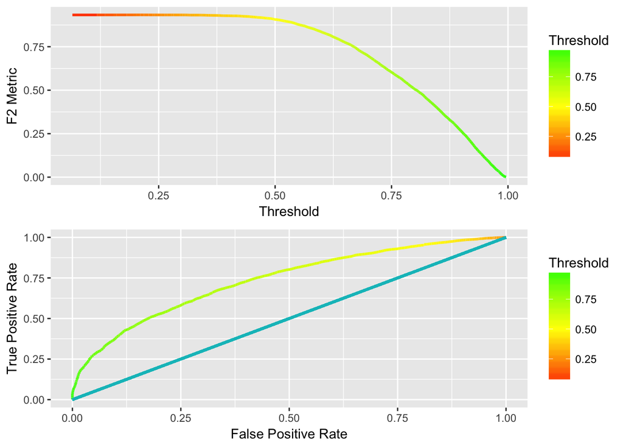

```r
grid.arrange(GBMet,GBMat,ncol=1)
```

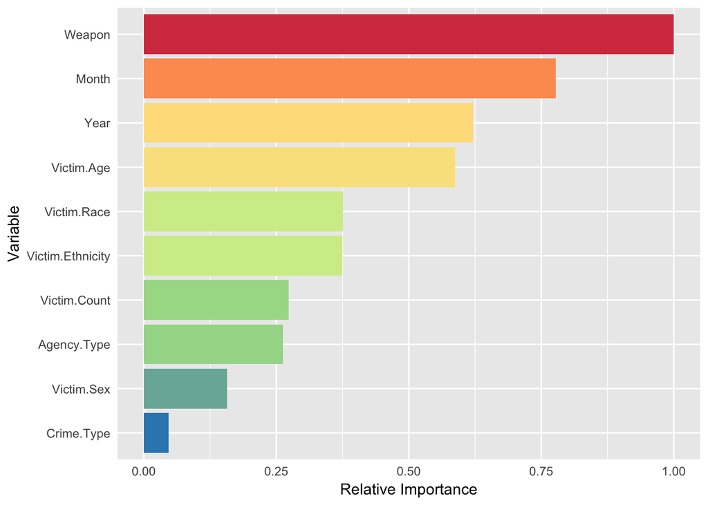

```r
ggplot(data.table(cbind(h2o.varimp(GBMb)$variable[1:10],h2o.varimp(GBMb)$scaled_importance[1:10],h2o.varimp(GBMb)$relative_importance[1:10])))+
  geom_col(aes(x=V1,y=as.numeric(V2),fill=as.numeric(V3))) +
  coord_flip() +
  scale_x_discrete(limits=rev(h2o.varimp(GBMb)$variable[1:10])) +
  scale_y_continuous(breaks=seq(0,1,0.25)) +
  theme(axis.ticks=element_blank()) +
  labs(x="Variable",y="Relative Importance") +
  scale_fill_distiller(palette="Spectral",guide=F)
```

```r
h2o.confusionMatrix(GBMp)[,1:3]
```

```
##         No   Yes      Error
## No     198  2532 0.92747253
## Yes     80  7491 0.01056664
## Totals 278 10023 0.25356761
```

```r
h2o.confusionMatrix(GBMt)[,1:3]
```

```
##         No  Yes      Error
## No     266 2460 0.90242113
## Yes    123 7451 0.01623977
## Totals 389 9911 0.25077670
```

# Shutdown

Now that the model processing has completed I shut down H20.

```r
h2o.shutdown()
```

## Conclusion

It seems that the Random Forest method provided the most accurate results, but it is interesting to note that for both methods among the highest determining predictors were the year and the month the crime took place, suggesting that when the crime took place is one of the largest factors in determining whether it will be solved or not.